# Analyzing Individual BGG Users

Phil Henrickson

2022-01-01

# **DarkJjay’s** BoardGameGeek Collection

This notebook contains a set of analyses for the selected user’s boardgamegeek collection. The bulk of the analysis is focused on building a user-specific predictive model to predict the games that DarkJjay is likely to own. This enables to ask questions like, based on the games the user currently owns, what games are a good fit for their collection? What upcoming games are they likely to purchase?

This analysis is based on data from BoardGameGeek that was last updated on **2021-12-20.**

# 1 Collection Overview

We can look at a basic description of the number of games that the user owns, has rated, has previously owned, etc.

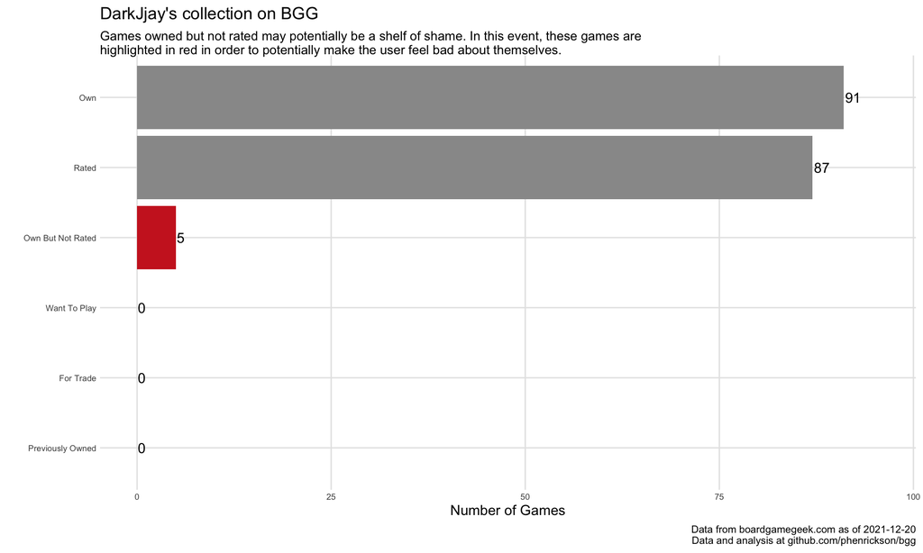

What years has the user owned/rated games from? While we can’t see when a user added or removed a game from their collection, we can look at their collection by the years in which their games were published.

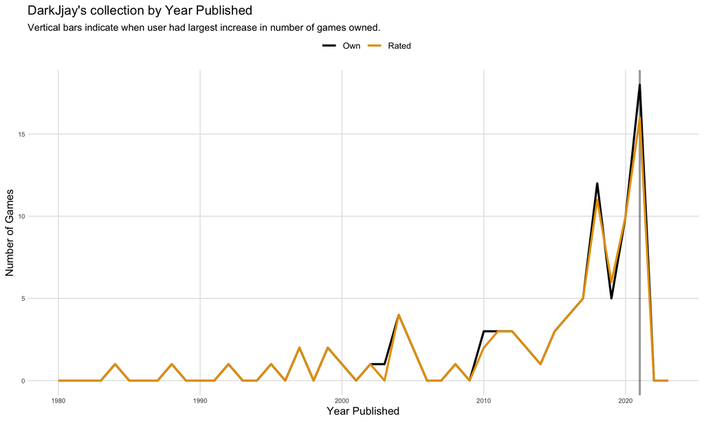

## 1.1 What types of games does DarkJjay own?

We can look at the most frequent types of categories, mechanics, designers, and artists that appear in a user’s collection.

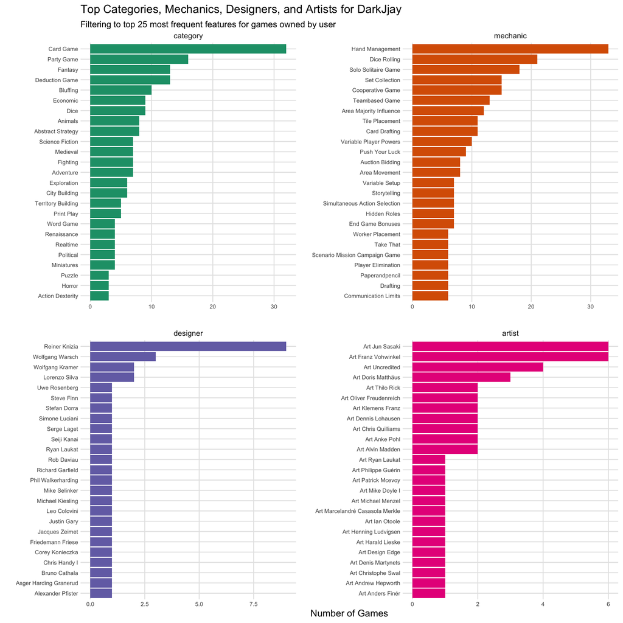

# 2 Modeling **DarkJjay’s** Collection

| username | dataset | period | games_owned | games_rated | games_played |
| --- | --- | --- | --- | --- | --- |
| DarkJjay | training | published before 2020 | 63 | 61 | 64 |
| DarkJjay | test | published 2020 or later | 28 | 26 | 28 |

There are two main (binary) outcomes we will be modeling for the user.

The first, **own** refers to whether the user currently lists a game as owned in their collection. The second, **played** refers to whether the user currently owns, has rated, or previously owned a game. This means the latter will generally have a larger list of games, but may still be a useful category to examine for people who play lots of games without necessarily owning them.

We will train predictive models to learn the probability that the user will own or play individual games based on their features.

## 2.1 Coefficients for DarkJjay

We can examine coefficients from the trained modes, which are penalized logistic regressions fit to our two main outcomes. Positive values indicate that a feature increases a user’s probabilility of owning/rating a game, while negative values indicate a feature decreases the probability.

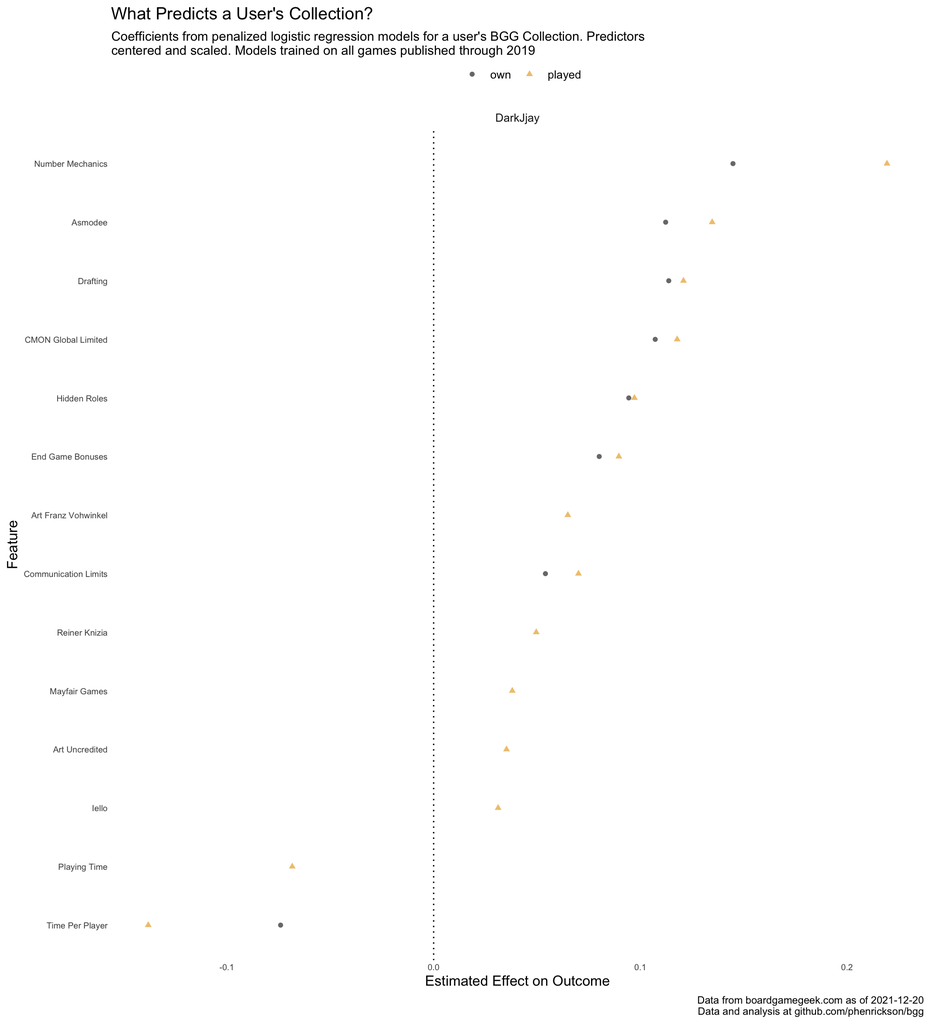

## 2.2 Visualizing Predictors for DarkJjay’s Collection

Why did the model identify these features? We can make density plots of the important features for predicting whether the user owned a game. Blue indicates the density for games owned by the user, while grey indicates the density for games not owned by the user.

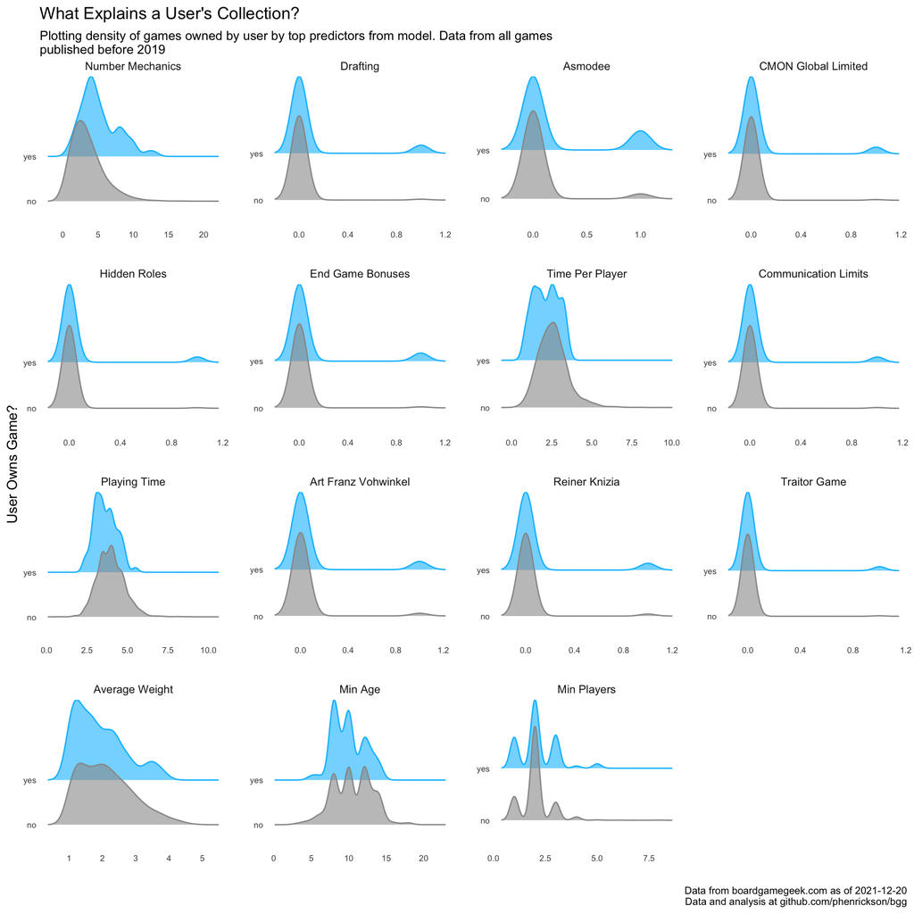

Binary predictors can be difficult to see with this visualization, so we can also directly examine the percentage of games in a user’s collection with a predictor vs the percentage of all games with that predictor.

| username | Feature | % of Games with Feature In_Collection | % of Games with Feature All_Games | Ratio |
| --- | --- | --- | --- | --- |
| DarkJjay | CMON Global Limited | 7.9% | 0.8% | 10.3 |
| DarkJjay | Drafting | 9.5% | 1.0% | 9.6 |
| DarkJjay | Hidden Roles | 6.3% | 0.7% | 9.2 |
| DarkJjay | End Game Bonuses | 9.5% | 1.2% | 7.7 |
| DarkJjay | Traitor Game | 4.8% | 0.7% | 7.3 |
| DarkJjay | Communication Limits | 6.3% | 1.0% | 6.6 |
| DarkJjay | Asmodee | 20.6% | 5.3% | 3.9 |
| DarkJjay | Word Game | 6.3% | 1.7% | 3.7 |
| DarkJjay | Party Game | 19.0% | 8.4% | 2.3 |
| DarkJjay | Deduction Game | 11.1% | 6.4% | 1.7 |
| DarkJjay | City Building | 6.3% | 4.3% | 1.5 |
| DarkJjay | Puzzle | 4.8% | 3.4% | 1.4 |
| DarkJjay | Medieval | 7.9% | 6.3% | 1.3 |
| DarkJjay | Horror | 4.8% | 4.0% | 1.2 |
| DarkJjay | Racing | 3.2% | 2.8% | 1.1 |
| DarkJjay | Realtime | 4.8% | 4.2% | 1.1 |
| DarkJjay | Trivia | 1.6% | 1.8% | 0.9 |
| DarkJjay | Murdermystery | 1.6% | 1.8% | 0.9 |
| DarkJjay | Sports | 1.6% | 2.0% | 0.8 |
| DarkJjay | Action Dexterity | 3.2% | 4.8% | 0.7 |
| DarkJjay | Trains | 1.6% | 2.2% | 0.7 |
| DarkJjay | Negotiation | 1.6% | 3.7% | 0.4 |
| DarkJjay | Childrens Game | 1.6% | 5.7% | 0.3 |
| DarkJjay | Mafia | 0.0% | 0.7% | 0.0 |
| DarkJjay | Prehistoric | 0.0% | 1.0% | 0.0 |

# 3 Assess Model’s Performance on Training Set

Before predicting games in upcoming years, we can examine how well the model did and what games it liked in the training set. In this case, we used resampling techniques (cross validation) to ensure that the model had not seen a game before making its predictions.

## 3.1 Separation Plot

An easy way to examine the performance of classification model is to view a separation plot. We plot the predicted probabilities from the model for every game (from resampling) from lowest to highest. We then overlay a blue line for any game that the user does own. A good classifier is one that is able to *separate* the blue (games owned by the user) from the white (games not owned by the user), with most of the blue occurring at the highest probabilities (right side of the chart).

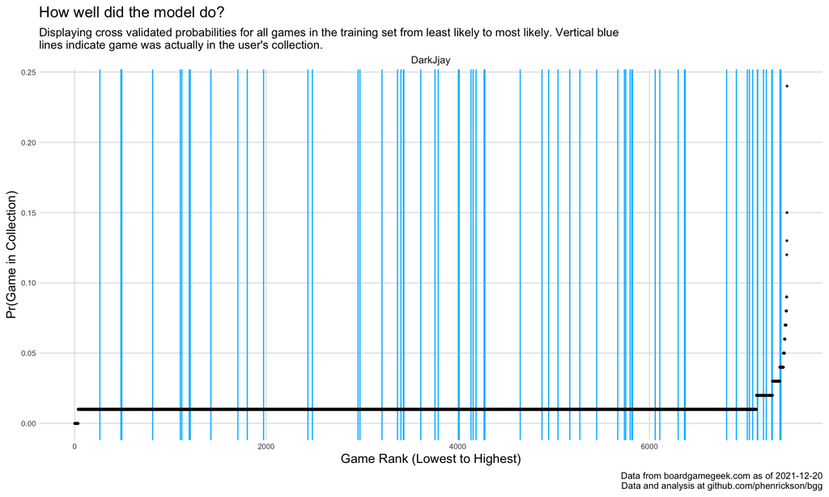

## 3.2 Top Games for **DarkJjay** from Training Set

We can display this information in table form, displaying the 100 games with the highest probability of ownership, adding a blue line when the user does own the game.

| username | yearpublished | game_id | name | pred_played | pred_own | actual_played | actual_own |
| --- | --- | --- | --- | --- | --- | --- | --- |
| DarkJjay | 2018 | 244711 | Newton | 0.47 | 0.24 | 0 | 0 |
| DarkJjay | 2000 | 478 | Citadels | 0.23 | 0.15 | 0 | 0 |
| DarkJjay | 2014 | 156129 | Deception: Murder in Hong Kong | 0.12 | 0.13 | 0 | 0 |
| DarkJjay | 2004 | 9220 | Saboteur | 0.09 | 0.12 | 0 | 0 |
| DarkJjay | 2017 | 184921 | Bunny Kingdom | 0.04 | 0.09 | 0 | 0 |
| DarkJjay | 2016 | 198454 | When I Dream | 0.05 | 0.09 | 0 | 0 |
| DarkJjay | 2017 | 234396 | Muse | 0.14 | 0.08 | 0 | 0 |
| DarkJjay | 2019 | 265736 | Tiny Towns | 0.04 | 0.08 | 0 | 0 |
| DarkJjay | 2018 | 245422 | Werewords Deluxe Edition | 0.11 | 0.08 | 0 | 0 |
| DarkJjay | 2012 | 128882 | The Resistance: Avalon | 0.02 | 0.08 | 0 | 0 |
| DarkJjay | 2014 | 147949 | One Night Ultimate Werewolf | 0.04 | 0.08 | 0 | 0 |
| DarkJjay | 2015 | 181687 | The Pursuit of Happiness | 0.03 | 0.07 | 0 | 0 |
| DarkJjay | 2017 | 228341 | Pulsar 2849 | 0.03 | 0.07 | 0 | 0 |
| DarkJjay | 2019 | 260710 | Amul | 0.05 | 0.07 | 0 | 0 |
| DarkJjay | 2015 | 163166 | One Night Ultimate Werewolf: Daybreak | 0.02 | 0.07 | 0 | 0 |
| DarkJjay | 2008 | 38159 | Ultimate Werewolf: Ultimate Edition | 0.04 | 0.07 | 0 | 0 |
| DarkJjay | 2016 | 72321 | The Networks | 0.10 | 0.07 | 0 | 0 |
| DarkJjay | 2019 | 266192 | Wingspan | 0.08 | 0.07 | 0 | 0 |
| DarkJjay | 2019 | 271324 | It's a Wonderful World | 0.08 | 0.07 | 0 | 0 |
| DarkJjay | 2016 | 195856 | Bloodborne: The Card Game | 0.06 | 0.07 | 0 | 0 |
| DarkJjay | 2017 | 217861 | Paper Tales | 0.05 | 0.07 | 0 | 0 |
| DarkJjay | 2018 | 205896 | Rising Sun | 0.78 | 0.07 | 0 | 0 |
| DarkJjay | 2018 | 199792 | Everdell | 0.03 | 0.06 | 0 | 0 |
| DarkJjay | 2017 | 231280 | Harvest Dice | 0.06 | 0.06 | 0 | 0 |
| DarkJjay | 2016 | 236217 | Timebomb | 0.06 | 0.06 | 0 | 0 |
| DarkJjay | 2018 | 225167 | Human Punishment: Social Deduction 2.0 | 0.04 | 0.06 | 0 | 0 |
| DarkJjay | 2008 | 37111 | Battlestar Galactica: The Board Game | 0.05 | 0.06 | 0 | 0 |
| DarkJjay | 2018 | 253106 | Narcos: The Board Game | 0.04 | 0.06 | 0 | 0 |
| DarkJjay | 2019 | 283294 | Yukon Airways | 0.05 | 0.05 | 0 | 0 |
| DarkJjay | 2012 | 108745 | Seasons | 0.05 | 0.05 | 0 | 0 |

[output cut: 70 more lines]

We can also more formally assess how well the model did in resampling by looking at the area under the receiver operating characteristic. A perfect model would receive a score of 1, while a model that cannot predict the outcome will default to a score of 0.5. The extent to which something is a *good* score depends on the setting, but generally anything in the .8 to .9 range is very good while the .7 to .8 range is perfectly acceptable.

| username | outcome_type | .metric | .estimator | .estimate |
| --- | --- | --- | --- | --- |
| DarkJjay | own | roc_auc | binary | 0.683 |
| DarkJjay | played | roc_auc | binary | 0.758 |

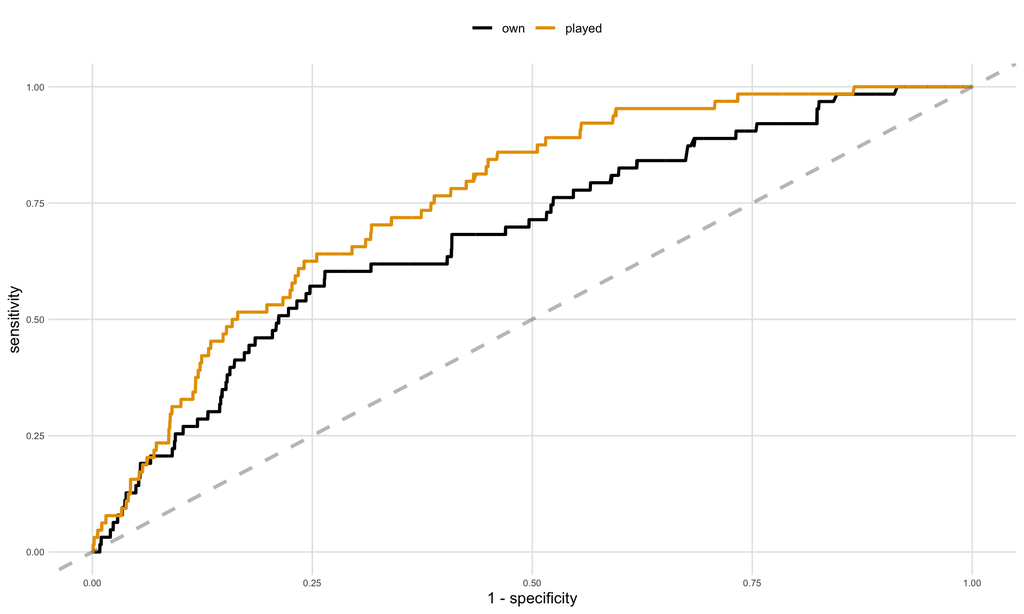

Another way to think about the model performance is to view its lift, or its ability to detect the positive outcomes over that of a null model. High lift indicates the model can much more quickly find all of the positive outcomes (in this case, games owned or played by the user), while a model with no lift is no better than random guessing.

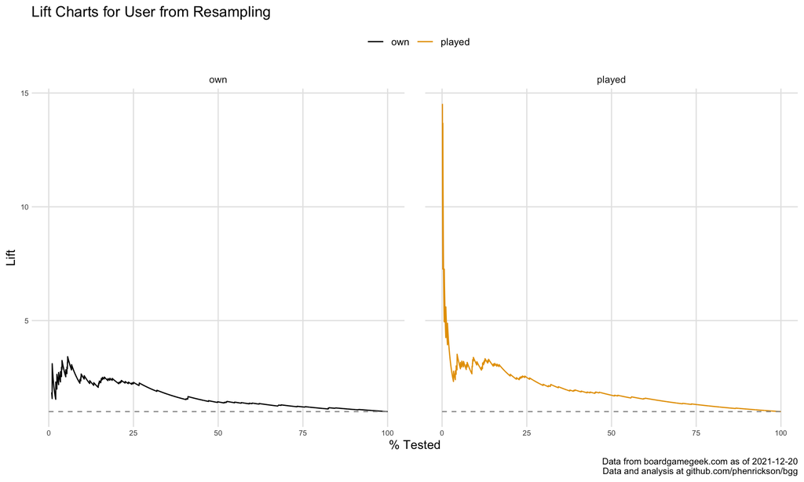

## 3.3 Most and Least Likely Games

What games does the model think DarkJjay is **most likely to own** that are **not** in their collection?

| username | yearpublished | game_id | name | pred_own | actual_own |
| --- | --- | --- | --- | --- | --- |
| DarkJjay | 2018 | 244711 | Newton | 0.24 | 0 |
| DarkJjay | 2000 | 478 | Citadels | 0.15 | 0 |
| DarkJjay | 2014 | 156129 | Deception: Murder in Hong Kong | 0.13 | 0 |
| DarkJjay | 2004 | 9220 | Saboteur | 0.12 | 0 |
| DarkJjay | 2017 | 184921 | Bunny Kingdom | 0.09 | 0 |

What games does the model think DarkJjay is **least likely to own** that **are** in their collection?

| username | yearpublished | game_id | name | pred_own | actual_own |
| --- | --- | --- | --- | --- | --- |
| DarkJjay | 2012 | 118048 | Targi | 0.01 | 1 |
| DarkJjay | 1999 | 50 | Lost Cities | 0.01 | 1 |
| DarkJjay | 1973 | 908 | Tally Ho! | 0.01 | 1 |
| DarkJjay | 2000 | 2655 | Hive | 0.01 | 1 |
| DarkJjay | 2011 | 43570 | Friday | 0.01 | 1 |

## 3.4 Top Games by Year

Top 25 games most likely to be owned by the user in each year, highlighting in blue the games that the user has owned/played.

[output not shown]

## 3.5 Interactive Predictions from Resampling

Interactive table for predictions from resampling.

|  | username | yearpublished | rank | game_id | name | pred_played | pred_own | actual_played | actual_own |
| --- | --- | --- | --- | --- | --- | --- | --- | --- | --- |
| 1 | DarkJjay | 1900 | 269 | 45 | Perudo | 0.04 | 0.02 | 0 | 0 |
| 2 | DarkJjay | 1900 | 335 | 5546 | Marbles | 0.01 | 0.01 | 0 | 0 |
| 3 | DarkJjay | 1900 | 337 | 11901 | Tic-Tac-Toe | 0.02 | 0.01 | 0 | 0 |
| 4 | DarkJjay | 1900 | 387 | 188 | Go | 0.01 | 0.01 | 0 | 0 |
| 5 | DarkJjay | 1900 | 495 | 171 | Chess | 0.01 | 0.01 | 0 | 0 |
| 6 | DarkJjay | 1900 | 506 | 2065 | Shogi | 0.01 | 0.01 | 0 | 0 |
| 7 | DarkJjay | 1900 | 508 | 2393 | Xiangqi | 0.01 | 0.01 | 0 | 0 |
| 8 | DarkJjay | 1900 | 747 | 26952 | International Checkers | 0.01 | 0.01 | 0 | 0 |
| 9 | DarkJjay | 1900 | 784 | 1602 | The Royal Game of Ur | 0.01 | 0.01 | 0 | 0 |
| 10 | DarkJjay | 1900 | 785 | 2083 | Checkers | 0.01 | 0.01 | 0 | 0 |

[output cut: 7426 more lines]

# 4 Validating the Model on 2020

How well did a model trained on a user’s collection through 2019 perform in predicting games for the user from 2020?

| username | outcome_type | yearpublished | .metric | .estimator | .estimate |
| --- | --- | --- | --- | --- | --- |
| DarkJjay | own | 2020 | roc_auc | binary | 0.773 |
| DarkJjay | played | 2020 | roc_auc | binary | 0.818 |

Table of top 25 games from 2020, highlighting games that the user owns.

| username | yearpublished | game_id | name | pred_own | pred_played | actual_own | actual_played |
| --- | --- | --- | --- | --- | --- | --- | --- |
| DarkJjay | 2020 | 184267 | On Mars | 0.08 | 0.11 | 0 | 0 |
| DarkJjay | 2020 | 297030 | Tekhenu: Obelisk of the Sun | 0.07 | 0.08 | 0 | 0 |
| DarkJjay | 2020 | 292333 | Cowboys II: Cowboys & Indians Edition | 0.05 | 0.07 | 0 | 0 |
| DarkJjay | 2020 | 297204 | Traintopia | 0.05 | 0.06 | 0 | 0 |
| DarkJjay | 2020 | 307844 | Atheneum: Mystic Library | 0.05 | 0.05 | 0 | 0 |
| DarkJjay | 2020 | 291457 | Gloomhaven: Jaws of the Lion | 0.04 | 0.07 | 1 | 1 |
| DarkJjay | 2020 | 299960 | Alma Mater | 0.04 | 0.04 | 0 | 0 |
| DarkJjay | 2020 | 302465 | Obsidia | 0.04 | 0.04 | 0 | 0 |
| DarkJjay | 2020 | 316377 | 7 Wonders (Second Edition) | 0.04 | 0.06 | 0 | 0 |
| DarkJjay | 2020 | 323784 | Ghost Letters | 0.04 | 0.05 | 0 | 0 |
| DarkJjay | 2020 | 252153 | Tang Garden | 0.03 | 0.03 | 0 | 0 |
| DarkJjay | 2020 | 256317 | Guild Master | 0.03 | 0.04 | 0 | 0 |
| DarkJjay | 2020 | 256999 | Project: ELITE | 0.03 | 0.03 | 0 | 0 |
| DarkJjay | 2020 | 257001 | Munchkin Dungeon | 0.03 | 0.03 | 0 | 0 |
| DarkJjay | 2020 | 257193 | Starcadia Quest | 0.03 | 0.03 | 0 | 0 |
| DarkJjay | 2020 | 261403 | Inhuman Conditions | 0.03 | 0.04 | 1 | 1 |
| DarkJjay | 2020 | 271002 | Myraclia | 0.03 | 0.03 | 0 | 0 |
| DarkJjay | 2020 | 298047 | Marvel United | 0.03 | 0.03 | 0 | 0 |
| DarkJjay | 2020 | 298638 | Sheriff of Nottingham (2nd Edition) | 0.03 | 0.03 | 0 | 0 |
| DarkJjay | 2020 | 301880 | Raiders of Scythia | 0.03 | 0.03 | 0 | 0 |
| DarkJjay | 2020 | 306481 | Tawantinsuyu: The Inca Empire | 0.03 | 0.04 | 0 | 0 |
| DarkJjay | 2020 | 307997 | Insider Black | 0.03 | 0.04 | 1 | 1 |
| DarkJjay | 2020 | 312762 | The Joker | 0.03 | 0.03 | 0 | 0 |
| DarkJjay | 2020 | 313817 | Hello Neighbor: The Secret Neighbor Party Game | 0.03 | 0.04 | 0 | 0 |
| DarkJjay | 2020 | 227224 | The Red Cathedral | 0.02 | 0.02 | 1 | 1 |

# 5 Predicting Upcoming Games (2020 and On) for **DarkJjay**

Examine the top games for the test set.

| username | yearpublished | game_id | name | rank | own | played |
| --- | --- | --- | --- | --- | --- | --- |
| DarkJjay | 2020 | 184267 | On Mars | 1 | 0.08 | 0.11 |
| DarkJjay | 2020 | 297030 | Tekhenu: Obelisk of the Sun | 2 | 0.07 | 0.08 |
| DarkJjay | 2020 | 307844 | Atheneum: Mystic Library | 3 | 0.05 | 0.05 |
| DarkJjay | 2020 | 297204 | Traintopia | 4 | 0.05 | 0.06 |
| DarkJjay | 2020 | 292333 | Cowboys II: Cowboys & Indians Edition | 5 | 0.05 | 0.07 |
| DarkJjay | 2020 | 302465 | Obsidia | 6 | 0.04 | 0.04 |
| DarkJjay | 2020 | 323784 | Ghost Letters | 7 | 0.04 | 0.05 |
| DarkJjay | 2020 | 291457 | Gloomhaven: Jaws of the Lion | 8 | 0.04 | 0.07 |
| DarkJjay | 2020 | 299960 | Alma Mater | 9 | 0.04 | 0.04 |
| DarkJjay | 2020 | 316377 | 7 Wonders (Second Edition) | 10 | 0.04 | 0.06 |
| DarkJjay | 2020 | 252153 | Tang Garden | 11 | 0.03 | 0.03 |
| DarkJjay | 2020 | 312762 | The Joker | 12 | 0.03 | 0.03 |
| DarkJjay | 2020 | 298638 | Sheriff of Nottingham (2nd Edition) | 13 | 0.03 | 0.03 |
| DarkJjay | 2020 | 298047 | Marvel United | 14 | 0.03 | 0.03 |
| DarkJjay | 2020 | 257193 | Starcadia Quest | 15 | 0.03 | 0.03 |
| DarkJjay | 2020 | 271002 | Myraclia | 16 | 0.03 | 0.03 |
| DarkJjay | 2020 | 301880 | Raiders of Scythia | 17 | 0.03 | 0.03 |
| DarkJjay | 2020 | 307997 | Insider Black | 18 | 0.03 | 0.04 |
| DarkJjay | 2020 | 261403 | Inhuman Conditions | 19 | 0.03 | 0.04 |
| DarkJjay | 2020 | 313817 | Hello Neighbor: The Secret Neighbor Party Game | 20 | 0.03 | 0.04 |
| DarkJjay | 2020 | 256999 | Project: ELITE | 21 | 0.03 | 0.03 |
| DarkJjay | 2020 | 256317 | Guild Master | 22 | 0.03 | 0.04 |
| DarkJjay | 2020 | 257001 | Munchkin Dungeon | 23 | 0.03 | 0.03 |
| DarkJjay | 2020 | 306481 | Tawantinsuyu: The Inca Empire | 24 | 0.03 | 0.04 |
| DarkJjay | 2020 | 310968 | Bite and Write: The Treaty of Rodentia | 25 | 0.02 | 0.02 |
| DarkJjay | 2021 | 291847 | Mantis Falls | 1 | 0.09 | 0.11 |
| DarkJjay | 2021 | 322588 | Origins: First Builders | 2 | 0.07 | 0.07 |
| DarkJjay | 2021 | 316786 | Tabannusi: Builders of Ur | 3 | 0.07 | 0.08 |
| DarkJjay | 2021 | 285967 | Ankh: Gods of Egypt | 4 | 0.06 | 0.08 |
| DarkJjay | 2021 | 291859 | Riftforce | 5 | 0.05 | 0.06 |
| DarkJjay | 2021 | 315624 | World Changers | 6 | 0.05 | 0.06 |
| DarkJjay | 2021 | 335541 | We Care: a Grizzled Game | 7 | 0.05 | 0.07 |
| DarkJjay | 2021 | 319999 | Dungeon Decorators | 8 | 0.05 | 0.06 |
| DarkJjay | 2021 | 340466 | Unfathomable | 9 | 0.04 | 0.04 |
| DarkJjay | 2021 | 249277 | Brazil: Imperial | 10 | 0.04 | 0.05 |
| DarkJjay | 2021 | 309408 | Arcana Rising | 11 | 0.04 | 0.04 |
| DarkJjay | 2021 | 298102 | Roll Camera!: The Filmmaking Board Game | 12 | 0.04 | 0.07 |
| DarkJjay | 2021 | 273330 | Bloodborne: The Board Game | 13 | 0.04 | 0.05 |
| DarkJjay | 2021 | 313262 | Shamans | 14 | 0.03 | 0.03 |
| DarkJjay | 2021 | 283387 | Rocketmen | 15 | 0.03 | 0.02 |
| DarkJjay | 2021 | 295947 | Cascadia | 16 | 0.03 | 0.03 |
| DarkJjay | 2021 | 301441 | Drawn to Adventure | 17 | 0.03 | 0.03 |
| DarkJjay | 2021 | 337262 | Fangs | 18 | 0.03 | 0.03 |
| DarkJjay | 2021 | 309250 | Empyrean Hero: The Card Game | 19 | 0.03 | 0.03 |
| DarkJjay | 2021 | 310100 | Nemesis: Lockdown | 20 | 0.03 | 0.03 |
| DarkJjay | 2021 | 301018 | Dragon Parks | 21 | 0.03 | 0.03 |
| DarkJjay | 2021 | 314393 | Wutaki | 22 | 0.03 | 0.03 |
| DarkJjay | 2021 | 314088 | Agropolis | 23 | 0.03 | 0.04 |
| DarkJjay | 2021 | 286751 | Zombicide: 2nd Edition | 24 | 0.03 | 0.03 |
| DarkJjay | 2021 | 336382 | Marvel United: X-Men | 25 | 0.03 | 0.03 |
| DarkJjay | 2022 | 320718 | Hidden Leaders | 1 | 0.03 | 0.03 |
| DarkJjay | 2022 | 315610 | Massive Darkness 2: Hellscape | 2 | 0.03 | 0.03 |
| DarkJjay | 2022 | 271601 | Feed the Kraken | 3 | 0.03 | 0.03 |
| DarkJjay | 2022 | 334065 | Verdant | 4 | 0.03 | 0.03 |
| DarkJjay | 2022 | 317511 | Tindaya | 5 | 0.03 | 0.05 |
| DarkJjay | 2022 | 283137 | Human Punishment: The Beginning | 6 | 0.03 | 0.04 |
| DarkJjay | 2022 | 336986 | Flamecraft | 7 | 0.02 | 0.02 |
| DarkJjay | 2022 | 322524 | Bardsung | 8 | 0.02 | 0.02 |
| DarkJjay | 2022 | 324090 | Scarface 1920 | 9 | 0.02 | 0.02 |
| DarkJjay | 2022 | 335427 | Wild: Serengeti | 10 | 0.02 | 0.02 |
| DarkJjay | 2022 | 326945 | Castles of Mad King Ludwig: Collector's Edition | 11 | 0.02 | 0.02 |
| DarkJjay | 2022 | 305096 | Endless Winter: Paleoamericans | 12 | 0.02 | 0.02 |
| DarkJjay | 2022 | 319807 | Shogun no Katana | 13 | 0.02 | 0.02 |
| DarkJjay | 2022 | 295374 | Long Shot: The Dice Game | 14 | 0.02 | 0.02 |
| DarkJjay | 2022 | 266064 | Trudvang Legends | 15 | 0.02 | 0.02 |
| DarkJjay | 2022 | 280726 | Legacies | 16 | 0.02 | 0.02 |
| DarkJjay | 2022 | 321608 | Hegemony: Lead Your Class to Victory | 17 | 0.02 | 0.02 |
| DarkJjay | 2022 | 331106 | The Witcher: Old World | 18 | 0.02 | 0.03 |
| DarkJjay | 2022 | 304051 | Creature Comforts | 19 | 0.02 | 0.03 |
| DarkJjay | 2022 | 240980 | Blood on the Clocktower | 20 | 0.02 | 0.02 |
| DarkJjay | 2022 | 295770 | Frosthaven | 21 | 0.02 | 0.03 |
| DarkJjay | 2022 | 316624 | Stationfall | 22 | 0.02 | 0.02 |
| DarkJjay | 2022 | 286158 | D.E.I.: Divide et Impera | 23 | 0.01 | 0.00 |
| DarkJjay | 2022 | 322354 | DEFCON 1 | 24 | 0.01 | 0.00 |
| DarkJjay | 2022 | 274056 | HEL: The Last Saga | 25 | 0.01 | 0.00 |

## 5.1 Interactive Table for Upcoming Games 2020 and On

|  | username | yearpublished | game_id | name | rank | own | played |
| --- | --- | --- | --- | --- | --- | --- | --- |
| 1 | DarkJjay | 2021 | 291847 | Mantis Falls | 1 | 0.09 | 0.11 |
| 2 | DarkJjay | 2020 | 184267 | On Mars | 2 | 0.08 | 0.11 |
| 3 | DarkJjay | 2021 | 322588 | Origins: First Builders | 3 | 0.07 | 0.07 |
| 4 | DarkJjay | 2020 | 297030 | Tekhenu: Obelisk of the Sun | 4 | 0.07 | 0.08 |
| 5 | DarkJjay | 2021 | 316786 | Tabannusi: Builders of Ur | 5 | 0.07 | 0.08 |
| 6 | DarkJjay | 2021 | 285967 | Ankh: Gods of Egypt | 6 | 0.06 | 0.08 |
| 7 | DarkJjay | 2021 | 291859 | Riftforce | 7 | 0.05 | 0.06 |
| 8 | DarkJjay | 2021 | 315624 | World Changers | 8 | 0.05 | 0.06 |
| 9 | DarkJjay | 2021 | 335541 | We Care: a Grizzled Game | 9 | 0.05 | 0.07 |
| 10 | DarkJjay | 2020 | 307844 | Atheneum: Mystic Library | 10 | 0.05 | 0.05 |

[output cut: 1627 more lines]